# Project MPDW : Peramalan Saham Unilever Menggunakan Pemodelan ARIMA-GARCH

Data yang kelompok 12 gunakan adalah data persentase saham Unilever di Indonesia 1 Januari 2018 - 30 Oktober 2023.

# Library

```r
library(ggplot2)
library(tsibble)
library(tseries)
library(MASS)
library(dplyr)
library(TTR)
library(forecast)
library(lmtest)
library(orcutt)
library(HoRM)
library(dLagM)
library(dynlm)
library(MLmetrics)
library(car)
library(TSA)
library(aTSA)
library(rugarch)
library(imputeTS)
library(tidyr)
```

# Impor Data

```r
#install.packages("rio") #install jika belum ada
library(rio)
datasaham <- import("https://raw.githubusercontent.com/aidara11/mpdw/main/Pertemuan%2011/Data%20Saham%20Unilever%202018-2023.csv")
head(datasaham)
```

```
##         Date  Open  High   Low Close Adj Close   Volume
## 1 2018-01-01 11180 11620 10635 10800  9254.643 44448000
## 2 2018-01-08 10800 10940 10700 10850  9297.488 43629500
## 3 2018-01-15 10850 11000 10850 10890  9331.764 59268000
## 4 2018-01-22 10890 11155 10860 10910  9348.902 44043000
## 5 2018-01-29 11000 11140 10500 11005  9430.310 59799500
## 6 2018-02-05 10790 11080 10700 11080  9494.579 75593000
```

## Cek data

```r
str(datasaham)         #struktur data
```

```
## 'data.frame':    305 obs. of  7 variables:
##  $ Date     : IDate, format: "2018-01-01" "2018-01-08" ...
##  $ Open     : num  11180 10800 10850 10890 11000 ...
##  $ High     : num  11620 10940 11000 11155 11140 ...
##  $ Low      : num  10635 10700 10850 10860 10500 ...
##  $ Close    : num  10800 10850 10890 10910 11005 ...
##  $ Adj Close: num  9255 9297 9332 9349 9430 ...
##  $ Volume   : int  44448000 43629500 59268000 44043000 59799500 75593000 35915500 50283000 56477500 71074000 ...
```

```r
dim(datasaham)         #dimensi data
```

```
## [1] 305   7
```

```r
sum(is.na(datasaham))  #cek data kosong
```

```
## [1] 0
```

Data persentase saham Unilever Indonesia tahun 2018 - 2023 terdiri dari 305 amatan. Peubah yang akan digunakan adalah peubah date dan close. Data saham Unilever sudah berformat numerik dan tidak terdapat data kosong.

## Ubah menjadi time series

```r
datasaham.ts <- ts(datasaham$Close)
```

## Plot Data Penuh

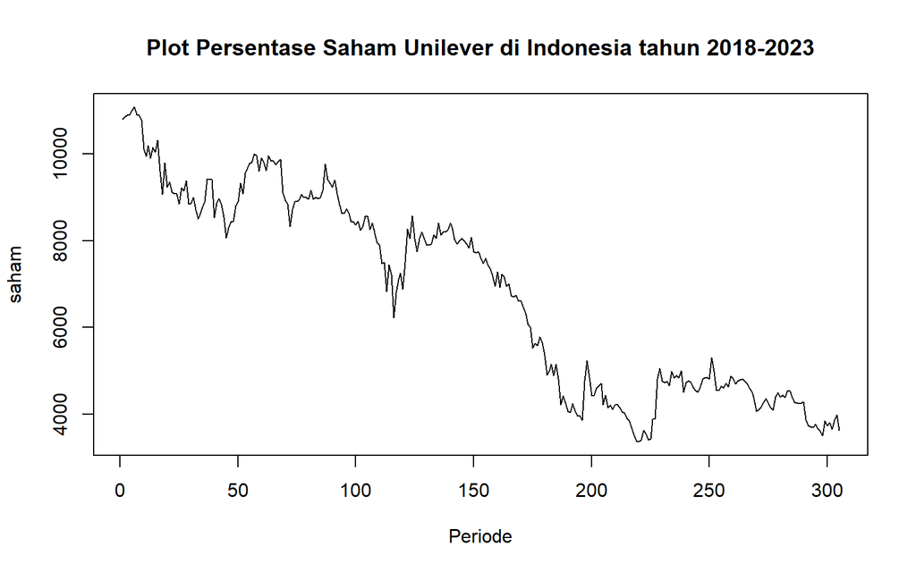

```r
plot.ts(datasaham.ts, lty=1, xlab="Periode", ylab="saham", main="Plot Persentase Saham Unilever di Indonesia tahun 2018-2023")
```

Berdasarkan plot data deret waktu, terlihat bahwa data cenderung memiliki trend yang turun. Berdasarkan pola data, pembagian data latih dan data uji ditetapkan dengan proporsi 80%:20%.

## Plot Data Latih

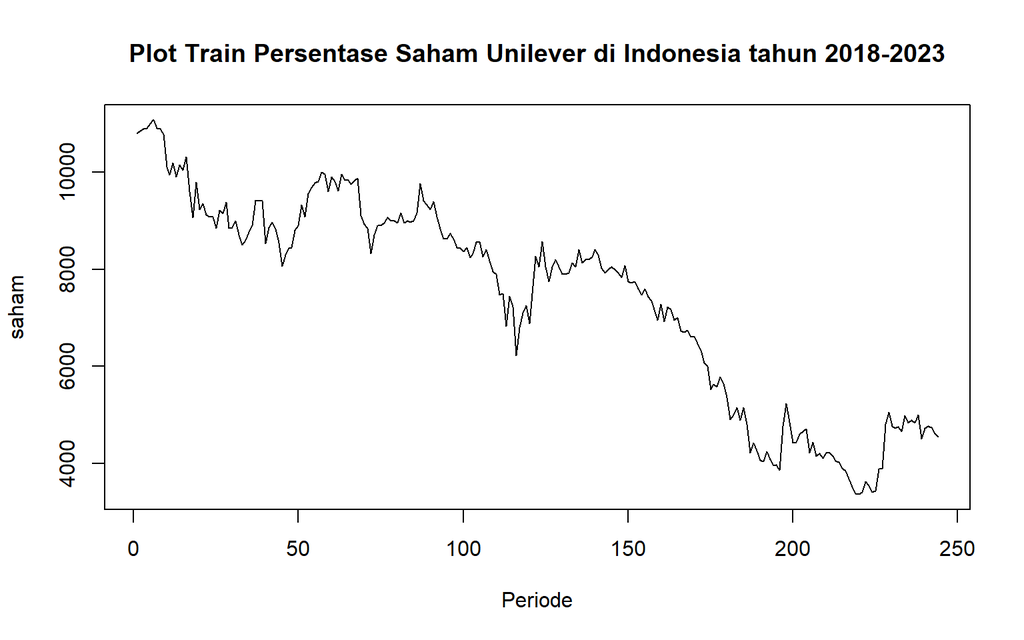

```r
sahamtrain <- datasaham.ts[1:244]
train.ts <- ts(sahamtrain)
plot.ts(train.ts, lty=1, xlab="Periode", ylab="saham", main="Plot Train Persentase Saham Unilever di Indonesia tahun 2018-2023")
```

Berdasarkan plot data deret waktu pada data latih, terlihat bahwa data cenderung memiliki trend yang turun dan cenderung tidak bergerak pada nilai tengah tertentu. Hal ini mengindikasikan bahwa data tidak stasioner dalam rataan.

## Plot Data Uji

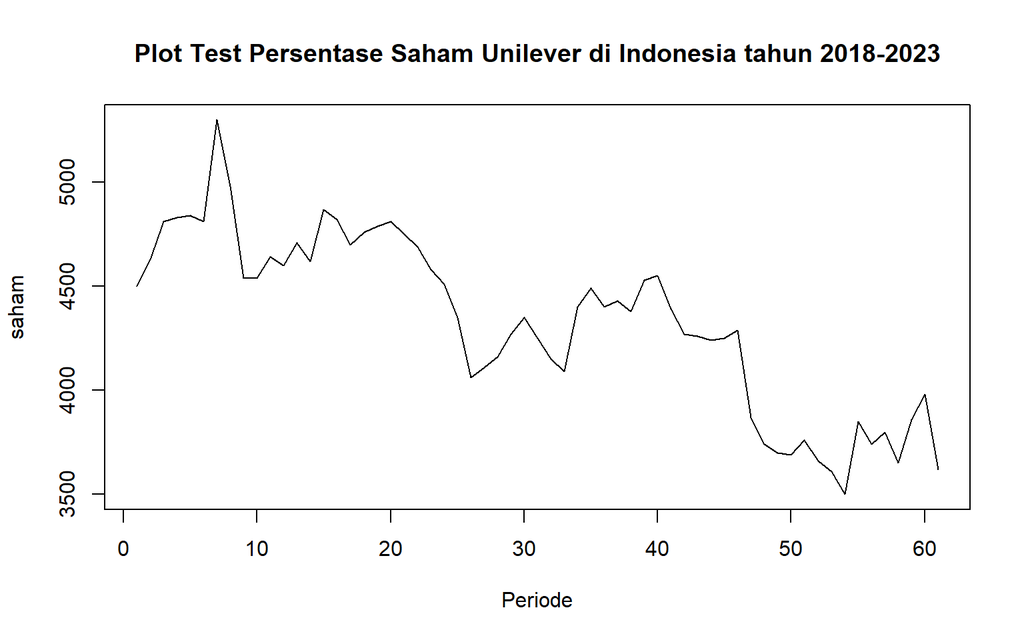

```r
sahamtest <- datasaham.ts[245:305]
test.ts <- ts(sahamtest)
plot.ts(test.ts, lty=1, xlab="Periode", ylab="saham", main="Plot Test Persentase Saham Unilever di Indonesia tahun 2018-2023")
```

Berdasarkan plot data deret waktu pada data uji, terlihat bahwa data cenderung memiliki trend yang turun dan cenderung tidak bergerak pada nilai tengah tertentu. Hal ini mengindikasikan bahwa data uji tidak stasioner dalam rataan.

## Cek pola data musiman

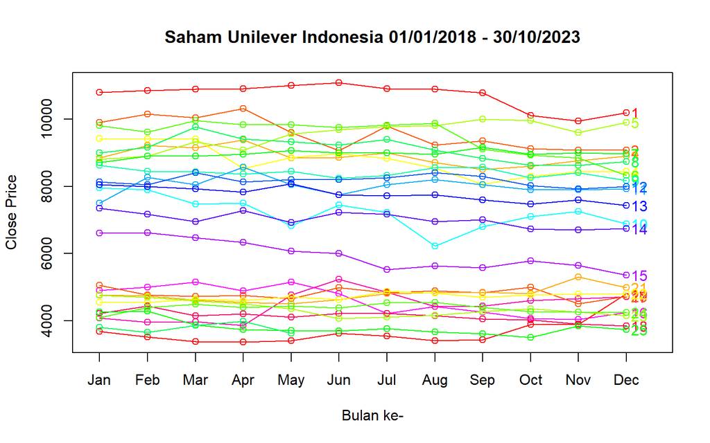

```r
seasonplot(datasaham.ts,12,
  main="Saham Unilever Indonesia 01/01/2018 - 30/10/2023",
  xlab = "Bulan ke-",
  ylab = "Close Price",
  year.labels = TRUE, col=rainbow(18))
```

Plot data menunjukkan bahwa data tidak berpola musiman.

# Uji Stasioneritas Data

## Plot ACF

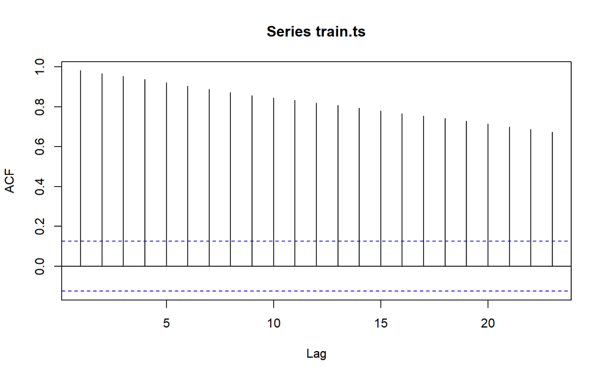

```r
acf(train.ts)
```

Berdasarkan plot ACF, terlihat bahwa plot ACF data train menurun secara perlahan (*tails of slowly*) dan tidak membentuk gelombang sinus. Hal ini juga menjadi indikasi bahwa data tidak stasioner dalam rataan.

## Uji ADF

```r
tseries::adf.test(train.ts)
```

```
##
##  Augmented Dickey-Fuller Test
##
## data:  train.ts
## Dickey-Fuller = -2.2889, Lag order = 6, p-value = 0.4543
## alternative hypothesis: stationary
```

Hipotesis

$H_0$ : Data tidak stasioner dalam rataan

$H_1$ : Data stasioner dalam rataan

Berdasarkan uji ADF tersebut, didapat *p-value* sebesar 0.4543 yang lebih besar dari taraf nyata 5% sehingga tak tolak $H_0$ dan menandakan bahwa data train tidak stasioner dalam rataan. Hal ini sesuai dengan hasil eksplorasi menggunakan plot time series dan plot ACF, sehingga ketidakstasioneran model kedepannya harus ditangani.

## Plot Box-Cox

```r
index <- seq(1:244)
bc = boxcox(train.ts~index, lambda = seq(-2, 4, by=.01))
```

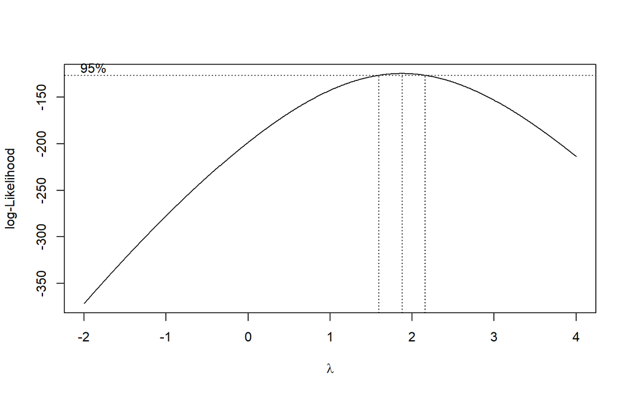

```r
#Nilai Rounded Lambda
lambda <- bc$x[which.max(bc$y)]
lambda
```

```
## [1] 1.88
```

```r
#SK
bc$x[bc$y > max(bc$y) - 1/2 * qchisq(.95,1)]
```

```
##  [1] 1.60 1.61 1.62 1.63 1.64 1.65 1.66 1.67 1.68 1.69 1.70 1.71 1.72 1.73 1.74
## [16] 1.75 1.76 1.77 1.78 1.79 1.80 1.81 1.82 1.83 1.84 1.85 1.86 1.87 1.88 1.89
## [31] 1.90 1.91 1.92 1.93 1.94 1.95 1.96 1.97 1.98 1.99 2.00 2.01 2.02 2.03 2.04
## [46] 2.05 2.06 2.07 2.08 2.09 2.10 2.11 2.12 2.13 2.14 2.15
```

Plot Boxcox menunjukkan nilai *rounded value* ($\lambda$) optimum sebesar **1.88** dan pada selang kepercayaan 95% nilai memiliki batas bawah **1.60** dan batas atas **2.15**. Selang tersebut tidak memuat nilai satu sehingga dapat dikatakan bahwa data train tidak stasioner dalam ragam.

# Penanganan Ketidakstasioneran Data

## Penanganan ketidakstasioneran ragam

### Transformasi Data

```r
train.ts.new <- (train.ts)^2
```

### Plot Box-Cox

```r
index <- seq(1:244)
bc = boxcox(train.ts.new~index, lambda = seq(-2, 4, by=.01))
```

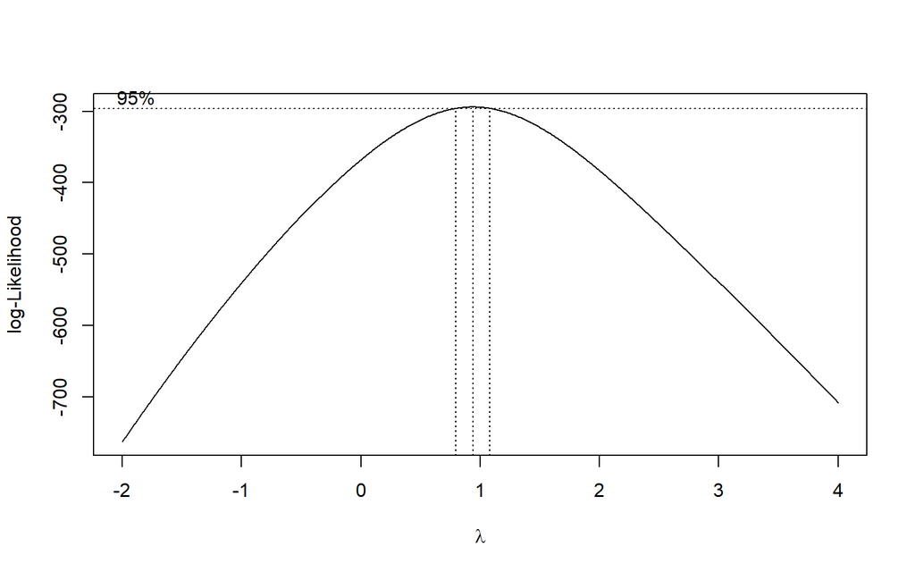

```r
#Nilai Rounded Lambda
lambda <- bc$x[which.max(bc$y)]
lambda
```

```
## [1] 0.94
```

```r
#SK
bc$x[bc$y > max(bc$y) - 1/2 * qchisq(.95,1)]
```

```
##  [1] 0.80 0.81 0.82 0.83 0.84 0.85 0.86 0.87 0.88 0.89 0.90 0.91 0.92 0.93 0.94
## [16] 0.95 0.96 0.97 0.98 0.99 1.00 1.01 1.02 1.03 1.04 1.05 1.06 1.07
```

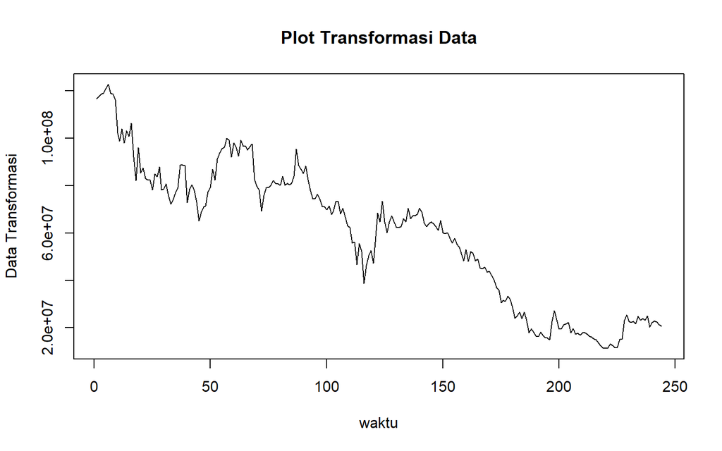

```r
plot.ts(train.ts.new, lty=1, xlab="waktu", ylab="Data Transformasi", main="Plot Transformasi Data")
```

Plot Boxcox menunjukkan nilai *rounded value* ($\lambda$) optimum sebesar **0.94** dan pada selang kepercayaan 95% nilai memiliki batas bawah **0.80** dan batas atas **1.07**. Selang tersebut memuat nilai satu sehingga dapat dikatakan bahwa data train stasioner dalam ragam.

## Penanganan ketidakstasioneran rataan

[figure not shown]

```r
train.diff <- diff(train.ts.new, differences = 1)
plot.ts(train.diff, lty=1, xlab="Periode", ylab="Data Difference 1 saham", main="Plot Difference Persentase saham di Indonesia tahun 2003-2023")
```

Berdasarkan plot data deret waktu, terlihat bahwa data sudah stasioner dalam rataan ditandai dengan data bergerak pada nilai tengah tertentu (tidak terdapat trend ataupun musiman pada data).

# Uji Stasioneritas Ulang

## Plot ACF (rataan)

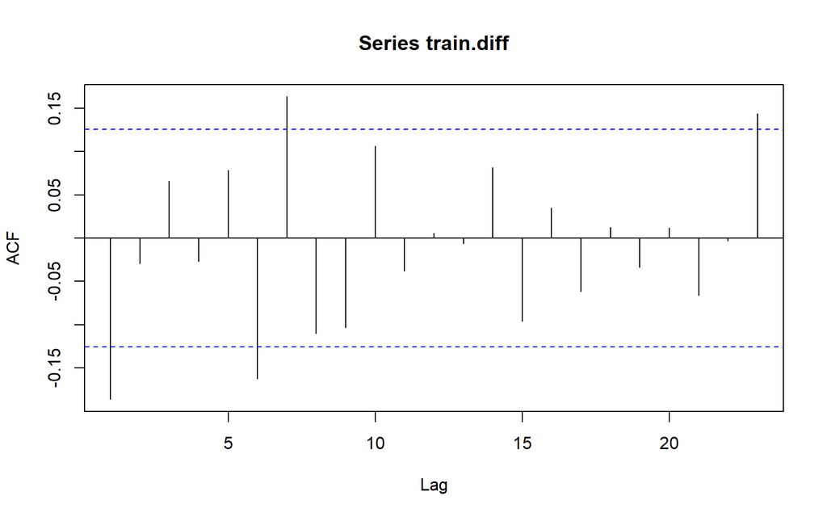

```r
acf(train.diff)
```

Berdasarkan plot tersebut, terlihat bahwa plot ACF cuts off pada lag ke 1. Hal ini menandakan data sudah stasioner dalam rataan dan ketidakstasioneran data telah berhasil tertangani.

## Uji ADF (rataan)

```r
tseries::adf.test(train.diff)
```

```
##
##  Augmented Dickey-Fuller Test
##
## data:  train.diff
## Dickey-Fuller = -5.5483, Lag order = 6, p-value = 0.01
## alternative hypothesis: stationary
```

$H_0$ : Data tidak stasioner dalam rataan

$H_1$ : Data stasioner dalam rataan

Berdasarkan uji ADF tersebut, didapat *p-value* sebesar 0.01 yang lebih kecil dari taraf nyata 5% sehingga tolak $H_0$ atau data stasioner dalam rataan. Hal ini sesuai dengan hasil eksplorasi menggunakan plot time series dan plot ACF, sehingga dalam hal ini ketidakstasioneran data sudah berhasil ditangani dan dapat dilanjutkan ke pemodelan.

# Identifikasi Model

## Plot ACF

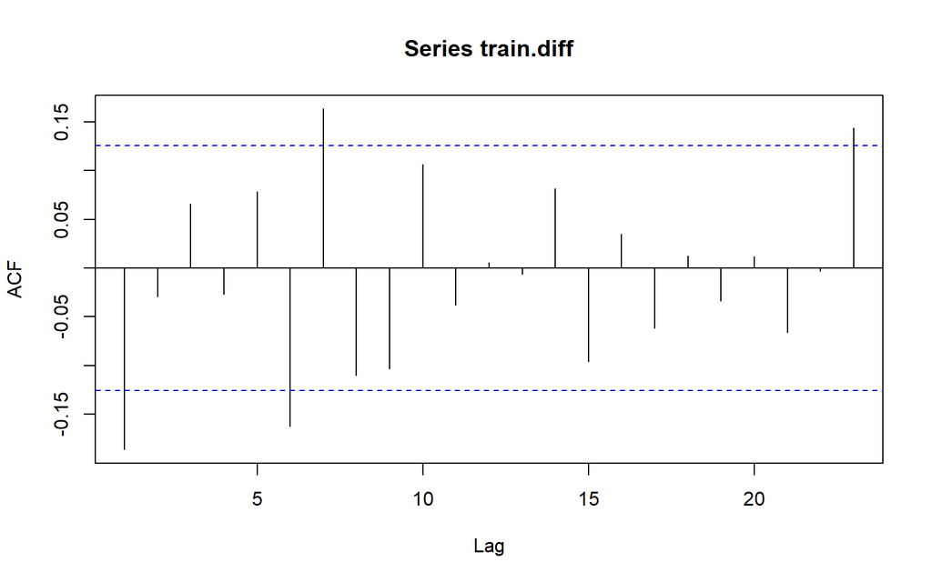

```r
acf(train.diff)
```

Berdasarkan plot tersebut, terlihat bahwa plot ACF cenderung *cuts off* pada lag ke 1, sehingga jika plot PACF dianggap *tails of*, maka model tentatifnya adalah ARIMA(0,1,1).

## Plot PACF

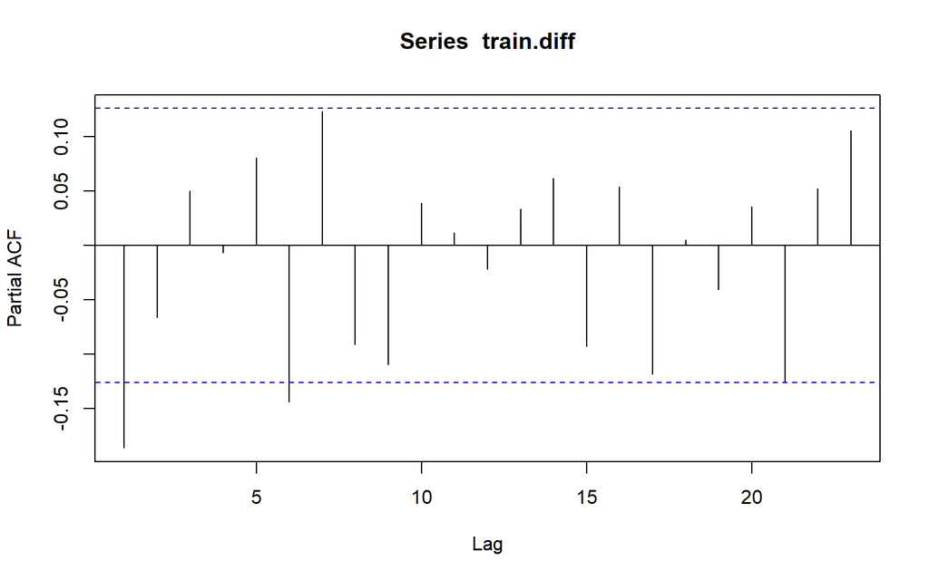

```r
pacf(train.diff)
```

Berdasarkan plot tersebut, terlihat bahwa plot PACF cenderung *cuts off* pada lag ke 1, sehingga jika plot ACF dianggap *tails of*, maka model tentatifnya adalah ARIMA(1,1,0).

## Plot EACF

```r
eacf(train.diff)
```

```
## AR/MA
##   0 1 2 3 4 5 6 7 8 9 10 11 12 13
## 0 x o o o o x x o o o o  o  o  o
## 1 x o o o o o o o o o o  o  o  o
## 2 x o o o o o o x o o o  o  o  o
## 3 x x x o o o o x o o o  o  o  o
## 4 o x x o o o o x o o o  o  o  o
## 5 x x x o o o o x o o o  o  o  o
## 6 x o x o x o o o o o o  o  o  o
## 7 x o x o x x x o o o o  o  o  o
```

# Pendugaan Parameter Model Tentatif

## ARIMA(1,1,1)

```r
model1.da=Arima(train.diff, order=c(1,1,1),method="ML")
summary(model1.da)
```

```
## Series: train.diff
## ARIMA(1,1,1)
##
## Coefficients:
##           ar1      ma1
##       -0.1820  -1.0000
## s.e.   0.0631   0.0129
##
## sigma^2 = 1.828e+13:  log likelihood = -4040.29
## AIC=8086.58   AICc=8086.68   BIC=8097.04
##
## Training set error measures:
##                    ME    RMSE     MAE MPE MAPE      MASE        ACF1
## Training set 165358.7 4249451 2985626 Inf  Inf 0.6305715 -0.01640867
```

```r
lmtest::coeftest(model1.da)
```

```
##
## z test of coefficients:
##
##      Estimate Std. Error  z value Pr(>|z|)
## ar1 -0.181974   0.063139  -2.8821  0.00395 **
## ma1 -0.999999   0.012881 -77.6340  < 2e-16 ***
## ---
## Signif. codes:  0 '***' 0.001 '**' 0.01 '*' 0.05 '.' 0.1 ' ' 1
```

Didapatkan nilai AIC sebesar 8086.58 dan seluruh parameter signifikan.

## ARIMA(1,1,2)

```r
model2.da=Arima(train.diff, order=c(1,1,2),method="ML")
summary(model2.da)
```

```
## Series: train.diff
## ARIMA(1,1,2)
##
## Coefficients:
##          ar1      ma1     ma2
##       0.0101  -1.2017  0.2017
## s.e.  0.2608   0.2528  0.2525
##
## sigma^2 = 1.831e+13:  log likelihood = -4040.01
## AIC=8088.02   AICc=8088.19   BIC=8101.97
##
## Training set error measures:
##                    ME    RMSE     MAE MPE MAPE   MASE        ACF1
## Training set 176891.6 4243691 2984340 NaN  Inf 0.6303 -0.00534698
```

```r
lmtest::coeftest(model2.da)
```

```
##
## z test of coefficients:
##
##      Estimate Std. Error z value  Pr(>|z|)
## ar1  0.010056   0.260820  0.0386    0.9692
## ma1 -1.201729   0.252797 -4.7537 1.997e-06 ***
## ma2  0.201734   0.252452  0.7991    0.4242
## ---
## Signif. codes:  0 '***' 0.001 '**' 0.01 '*' 0.05 '.' 0.1 ' ' 1
```

Didapatkan nilai AIC sebesar 8088.02 dan hanya parameter ma1 signifikan.

## ARIMA(1,1,3)

```r
model3.da=Arima(train.diff, order=c(1,1,3),method="ML")
summary(model3.da)
```

```
## Series: train.diff
## ARIMA(1,1,3)
##
## Coefficients:
##           ar1      ma1      ma2     ma3
##       -0.7590  -0.4066  -0.7953  0.2019
## s.e.   0.1277   0.1329   0.1242  0.0580
##
## sigma^2 = 1.818e+13:  log likelihood = -4038.68
## AIC=8087.36   AICc=8087.62   BIC=8104.81
##
## Training set error measures:
##                    ME    RMSE     MAE MPE MAPE      MASE       ACF1
## Training set 182522.8 4219799 2997959 NaN  Inf 0.6331763 -0.0187956
```

```r
lmtest::coeftest(model3.da)
```

```
##
## z test of coefficients:
##
##      Estimate Std. Error z value  Pr(>|z|)
## ar1 -0.759026   0.127729 -5.9425 2.808e-09 ***
## ma1 -0.406616   0.132918 -3.0591 0.0022197 **
## ma2 -0.795273   0.124245 -6.4008 1.545e-10 ***
## ma3  0.201889   0.057963  3.4831 0.0004957 ***
## ---
## Signif. codes:  0 '***' 0.001 '**' 0.01 '*' 0.05 '.' 0.1 ' ' 1
```

Didapatkan nilai AIC sebesar 8087.36 dan seluruh parameter signifikan.

## ARIMA(2,1,2)

```r
model4.da=Arima(train.diff, order=c(2,1,2),method="ML")
summary(model4.da)
```

```
## Series: train.diff
## ARIMA(2,1,2)
##
## Coefficients:
##           ar1      ar2      ma1      ma2
##       -0.9764  -0.2263  -0.2061  -0.7939
## s.e.   0.1143   0.0624   0.1018   0.1014
##
## sigma^2 = 1.808e+13:  log likelihood = -4037.98
## AIC=8085.97   AICc=8086.22   BIC=8103.41
##
## Training set error measures:
##                  ME    RMSE     MAE MPE MAPE      MASE        ACF1
## Training set 174139 4207933 2999397 NaN  Inf 0.6334799 0.001234364
```

```r
lmtest::coeftest(model4.da)
```

```
##
## z test of coefficients:
##
##      Estimate Std. Error z value  Pr(>|z|)
## ar1 -0.976416   0.114276 -8.5443 < 2.2e-16 ***
## ar2 -0.226283   0.062436 -3.6242 0.0002898 ***
## ma1 -0.206053   0.101756 -2.0250 0.0428695 *
## ma2 -0.793942   0.101433 -7.8273 4.985e-15 ***
## ---
## Signif. codes:  0 '***' 0.001 '**' 0.01 '*' 0.05 '.' 0.1 ' ' 1
```

Didapatkan nilai AIC sebesar 8085.97 dan seluruh parameter signifikan.

## ARIMA(2,1,3)

```r
model5.da=Arima(train.diff, order=c(2,1,3),method="ML")
summary(model5.da)
```

```
## Series: train.diff
## ARIMA(2,1,3)
##
## Coefficients:
```

```
##           ar1      ar2     ma1      ma2      ma3
##       -1.8311  -0.9794  0.8465  -0.8702  -0.9672
## s.e.      NaN      NaN     NaN   0.0225      NaN
##
## sigma^2 = 1.762e+13:  log likelihood = -4034.81
## AIC=8081.61   AICc=8081.97   BIC=8102.54
##
## Training set error measures:
##                    ME    RMSE     MAE MPE MAPE      MASE       ACF1
## Training set 137023.4 4145921 2934886 NaN  Inf 0.6198551 -0.1339302
```

```r
lmtest::coeftest(model5.da)
```

```
##
## z test of coefficients:
##
##      Estimate Std. Error z value  Pr(>|z|)
## ar1 -1.831055        NaN     NaN       NaN
## ar2 -0.979383        NaN     NaN       NaN
## ma1  0.846472        NaN     NaN       NaN
## ma2 -0.870232   0.022489 -38.697 < 2.2e-16 ***
## ma3 -0.967179        NaN     NaN       NaN
## ---
## Signif. codes:  0 '***' 0.001 '**' 0.01 '*' 0.05 '.' 0.1 ' ' 1
```

Didapatkan nilai AIC sebesar 8081.61 dan hanya parameter ma2 signifikan.

## ARIMA(2,1,4)

```r
model6.da=Arima(train.diff, order=c(2,1,4),method="ML")
summary(model6.da)
```

```
## Series: train.diff
## ARIMA(2,1,4)
##
## Coefficients:
##           ar1     ar2      ma1      ma2     ma3      ma4
##       -0.4777  0.1434  -0.6999  -0.5667  0.3841  -0.1175
## s.e.   1.2844  0.9836   1.2810   0.5450  1.0224   0.2621
##
## sigma^2 = 1.825e+13:  log likelihood = -4038.04
## AIC=8090.07   AICc=8090.55   BIC=8114.5
##
## Training set error measures:
##                    ME    RMSE     MAE MPE MAPE      MASE         ACF1
## Training set 158343.3 4209853 3001530 NaN  Inf 0.6339305 -0.005857749
```

```r
lmtest::coeftest(model6.da)
```

```
##
## z test of coefficients:
##
##     Estimate Std. Error z value Pr(>|z|)
## ar1 -0.47773    1.28440 -0.3719   0.7099
## ar2  0.14339    0.98357  0.1458   0.8841
## ma1 -0.69993    1.28103 -0.5464   0.5848
## ma2 -0.56669    0.54501 -1.0398   0.2984
## ma3  0.38415    1.02235  0.3757   0.7071
## ma4 -0.11752    0.26214 -0.4483   0.6539
```

Didapatkan nilai AIC sebesar 8090.07 dan seluruh parameter tudak signifikan.

# Overfitting

Tahapan selanjutnya adalah overfitting dilakukan dengan menaikkan orde AR(p) dan MA(q) dari model ARIMA(2,1,2) untuk melihat apakah terdapat model lain yang lebih baik dari model saat ini. Kandidat model overfitting adalah ARIMA(3,1,2) dan ARIMA(2,1,3).

## ARIMA(3,1,2)

```r
model5.1da=Arima(train.diff, order=c(3,1,2),method="ML")
summary(model5.1da)
```

```
## Series: train.diff
## ARIMA(3,1,2)
##
## Coefficients:
##           ar1      ar2     ar3      ma1      ma2
##       -0.9512  -0.1930  0.0338  -0.2245  -0.7755
## s.e.   0.1265   0.0913  0.0681   0.1104   0.1100
##
## sigma^2 = 1.814e+13:  log likelihood = -4037.86
## AIC=8087.73   AICc=8088.08   BIC=8108.66
##
## Training set error measures:
##                    ME    RMSE     MAE MPE MAPE      MASE         ACF1
## Training set 166545.9 4206294 2998926 NaN  Inf 0.6333805 -0.003975975
```

```r
lmtest::coeftest(model5.1da)
```

```
##
## z test of coefficients:
##
##      Estimate Std. Error z value  Pr(>|z|)
## ar1 -0.951159   0.126508 -7.5186 5.539e-14 ***
## ar2 -0.192956   0.091334 -2.1126   0.03463 *
## ar3  0.033800   0.068135  0.4961   0.61984
## ma1 -0.224463   0.110354 -2.0340   0.04195 *
## ma2 -0.775534   0.110048 -7.0473 1.825e-12 ***
## ---
## Signif. codes:  0 '***' 0.001 '**' 0.01 '*' 0.05 '.' 0.1 ' ' 1
```

Didapatkan nilai AIC sebesar 8087.73 dan hanya parameter ar3 tidak signifikan.

## ARIMA(2,1,3)

```r
model5.2da=Arima(train.diff, order=c(2,1,3),method="ML")
summary(model5.2da)
```

```
## Series: train.diff
## ARIMA(2,1,3)
##
## Coefficients:
```

```
##           ar1      ar2     ma1      ma2      ma3
##       -1.8311  -0.9794  0.8465  -0.8702  -0.9672
## s.e.      NaN      NaN     NaN   0.0225      NaN
##
## sigma^2 = 1.762e+13:  log likelihood = -4034.81
## AIC=8081.61   AICc=8081.97   BIC=8102.54
##
## Training set error measures:
##                    ME    RMSE     MAE MPE MAPE      MASE       ACF1
## Training set 137023.4 4145921 2934886 NaN  Inf 0.6198551 -0.1339302
```

```r
lmtest::coeftest(model5.2da)
```

```
##
## z test of coefficients:
##
##      Estimate Std. Error z value  Pr(>|z|)
## ar1 -1.831055        NaN     NaN       NaN
## ar2 -0.979383        NaN     NaN       NaN
## ma1  0.846472        NaN     NaN       NaN
## ma2 -0.870232   0.022489 -38.697 < 2.2e-16 ***
## ma3 -0.967179        NaN     NaN       NaN
## ---
## Signif. codes:  0 '***' 0.001 '**' 0.01 '*' 0.05 '.' 0.1 ' ' 1
```

Didapatkan nilai AIC sebesar 8081.61 dan hanya parameter ma2 yang signifikan.

# Analisis Sisaan

Model terbaik hasil identifikasi kemudian dicek asumsi sisaannya. Sisaan model ARIMA harus memenuhi asumsi normalitas, kebebasan sisaan, dan kehomogenan ragam. Diagnostik model dilakukan secara eksplorasi dan uji formal.

## Eksplorasi Sisaan

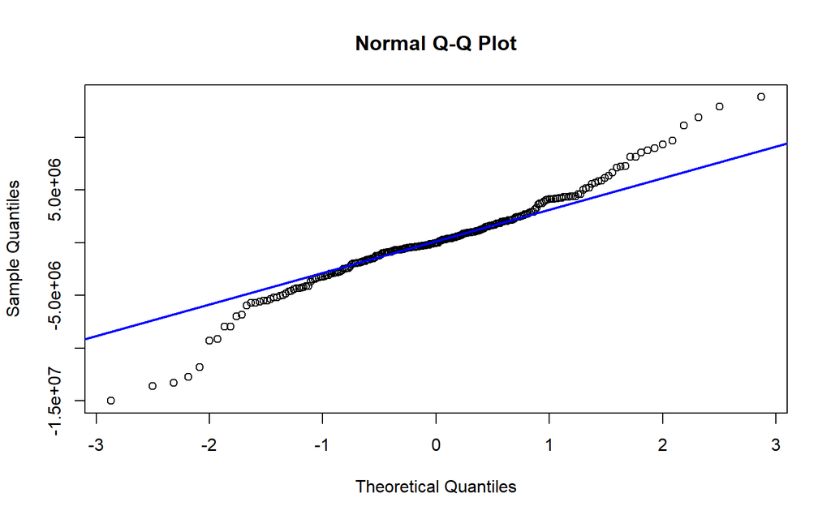

```r
sisaan.da <- model4.da$residuals
#par(mfrow=c(2,2))
qqnorm(sisaan.da)
qqline(sisaan.da, col = "blue", lwd = 2)
```

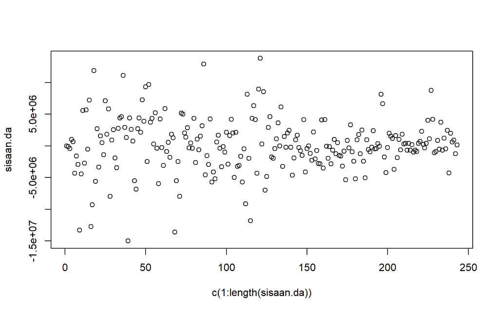

```r
plot(c(1:length(sisaan.da)),sisaan.da)
```

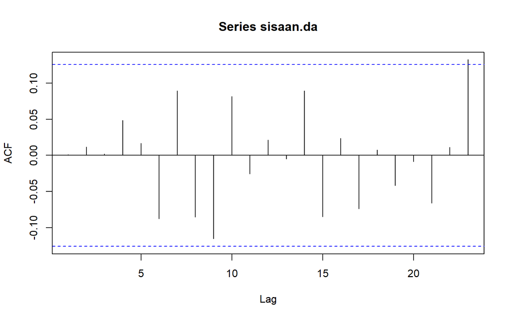

```r
acf(sisaan.da)
```

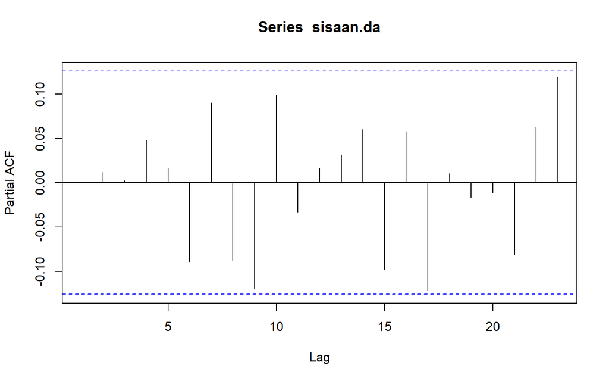

```r
pacf(sisaan.da)
```

```r
par(mfrow = c(1,1))
```

Berdasarkan plot kuantil-kuantil normal, secara eksplorasi ditunjukkan sisaan tidak menyebar normal ditandai dengan titik titik yang cenderung tidak mengikuti garis $45^{\circ}$ pada kedua ujungnya. Kemudian dapat dilihat juga lebar pita sisaan yang cenderung tidak sama menandakan bahwa sisaan memiliki ragam yang tidak homogen. Plot ACF dan PACF sisaan ARIMA(2,1,2) juga tidak signifikan pada 20 lag awal yang menandakan saling bebas. Kondisi ini akan diuji lebih lanjut dengan uji formal.

## Uji Formal

### 1. Uji kenormalanan sisaan

```r
ks.test(sisaan.da,"pnorm")  #tak tolak H0 > sisaan menyebar normal
```

```
##
##  Asymptotic one-sample Kolmogorov-Smirnov test
##
## data:  sisaan.da
## D = 0.50206, p-value < 2.2e-16
## alternative hypothesis: two-sided
```

Uji formal yang digunakan untuk normalitas adalah uji Kolmogorov-Smirnov (KS).

Hipotesis

$H_0$ : Sisaan menyebar normal

$H_1$ : Sisaan tidak menyebar normal

Berdasarkan uji KS tersebut, didapat *p-value* sebesar 2.2e-16 yang kurang dari taraf nyata 5% sehingga tolak $H_0$ dan menandakan bahwa sisaan tidak menyebar normal. Hal ini sesuai dengan hasil eksplorasi menggunakan plot kuantil-kuantil normal.

### 2. Uji kebebasan sisaan (tidak ada autokorelasi)

```r
Box.test(sisaan.da, type = "Ljung")  #tak tolak H0 > sisaan saling bebas
```

```
##
##  Box-Ljung test
##
## data:  sisaan.da
## X-squared = 0.00037484, df = 1, p-value = 0.9846
```

Uji formal untuk kebebasan sisaan menggunakan uji Ljung-Box.

Hipotesis

$H_0$ : Sisaan saling bebas

$H_1$ : Sisaan tidak tidak saling bebas

Berdasarkan uji Ljung-Box tersebut, didapat *p-value* sebesar 0.9846 yang lebih besar dari taraf nyata 5% sehingga tak tolak $H_0$ dan menandakan bahwa sisaan saling bebas. Hal ini sesuai dengan hasil eksplorasi menggunakan plot ACF dan PACF.

### 3. Uji kehomogenan sisaan

```r
Box.test((sisaan.da)^2, type = "Ljung")  #tak tolak H0 > sisaan homogen
```

```
##
##  Box-Ljung test
##
## data:  (sisaan.da)^2
## X-squared = 5.6939, df = 1, p-value = 0.01702
```

Hipotesis

$H_0$ : Ragam sisaan homogen

$H_1$ : Ragam sisaan tidak homogen

Berdasarkan uji Ljung-Box terhadap sisaan kuadrat tersebut, didapat *p-value* sebesar 0.01702 yang kurang dari taraf nyata 5% sehingga tolak $H_0$ dan menandakan bahwa ragam sisaan tidak homogen sehingga perlu dilakukan penanganan.

### 4. Nilai tengah sisaan sama dengan nol

```r
t.test(sisaan.da, mu = 0, conf.level = 0.95)  #tak tolak h0 > nilai tengah sisaan sama dengan 0
```

```
##
##  One Sample t-test
##
## data:  sisaan.da
## t = 0.64433, df = 242, p-value = 0.52
## alternative hypothesis: true mean is not equal to 0
## 95 percent confidence interval:
##  -358232  706510
## sample estimates:
## mean of x
##    174139
```

Terakhir, dengan uji-t, akan dicek apakah nilai tengah sisaan sama dengan nol.

Hipotesis

$H_0$ : nilai tengah sisaan sama dengan 0

$H_1$ : nilai tengah sisaan tidak sama dengan 0

Berdasarkan uji-ttersebut, didapat *p-value* sebesar 0.52 yang lebih besar dari taraf nyata 5% sehingga tak tolak $H_0$ dan menandakan bahwa nilai tengah sisaan sama dengan nol.

# Peramalan ARIMA

Peramalan dilakukan menggunakan fungsi forecast() . Contoh peramalan berikut ini dilakukan untuk 61 hari ke depan.

```r
ramalan.da <- forecast::forecast(model4.da, h = 61)
ramalan.da
```

```
##     Point Forecast    Lo 80   Hi 80    Lo 95   Hi 95
## 245       23309.79 -5436937 5483556 -8327416 8374036
## 246     -768576.40 -6314955 4777802 -9251030 7713877
## 247     -125005.94 -5676736 5426724 -8615644 8365632
## 248     -574207.96 -6148312 4999896 -9099064 7950648
## 249     -281229.03 -5869062 5306604 -8827082 8264624
## 250     -465651.54 -6062046 5130743 -9024599 8093295
## 251     -351874.62 -5950934 5247185 -8914897 8211147
## 252     -421236.53 -6022010 5179537 -8986880 8144407
## 253     -379256.24 -5980288 5221775 -8945295 8186783
## 254     -404551.04 -6005921 5196819 -8971107 8162005
## 255     -389352.22 -5990700 5211996 -8955874 8177170
## 256     -398468.81 -5999896 5202959 -8965113 8168176
## 257     -393006.46 -5994410 5208397 -8959614 8173601
## 258     -396277.06 -5997704 5205150 -8962920 8170366
```

[output cut: 47 more lines]

## Plot Ramalan

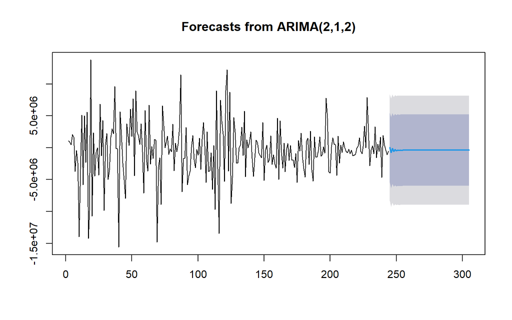

```r
data.ramalan.da <- ramalan.da$mean
plot(ramalan.da)
```

Dapat dilihat bahwa ramalan ARIMA(2,1,2) cenderung stabil hingga akhir periode. Selanjutnya, dapat dicari nilai akurasi antara hasil ramalan dengan data uji sebagai berikut.

## Transformasi Balik

```r
pt_1 <- train.ts.new[244] #nilai akhir data latih
hasil.forc.Diff <- data.ramalan.da
hasil <- diffinv(hasil.forc.Diff, differences = 1) + pt_1
hasil1 <- abs(hasil)^(1/2)
```

## Akurasi

Selanjutnya, dapat dicari nilai akurasi antara hasil ramalan yang sudah ditransformasi balik dengan data uji sebagai berikut.

```r
perbandingan<-matrix(data=c(head(test.ts, n=61),  hasil1[-1]),
                     nrow = 61, ncol = 2)
colnames(perbandingan)<-c("Aktual","Hasil Forecast")
head(perbandingan)
```

```
##      Aktual Hasil Forecast
## [1,]   4500       4552.561
## [2,]   4630       4467.352
## [3,]   4810       4453.339
## [4,]   4830       4388.396
## [5,]   4840       4356.236
## [6,]   4810       4302.457
```

```r
accuracy(ts(hasil1[-1]), head(test.ts, n=61))
```

```
##                ME     RMSE      MAE     MPE     MAPE      ACF1 Theil's U
## Test set 1554.736 1771.741 1556.459 37.6996 37.73789 0.9426983   11.6904
```

Diperoleh nilai MAPE sebesar 37.73789 yang menandakan bahwa hasil peramalan dari model ARIMA(2,1,2) masih kurang baik.

# Penanganan Ketidakhomogenan Ragam Sisaan

## Uji Efek ARCH

### ARCH(1)

```r
bydArchTest1 <- ArchTest(sisaan.da, lags=1, demean=TRUE)
bydArchTest1
```

```
##
##  ARCH LM-test; Null hypothesis: no ARCH effects
##
## data:  sisaan.da
## Chi-squared = 5.5368, df = 1, p-value = 0.01862
```

Didapatkan p-value sebesar 0.01862 kurang dari taraf nyata 5%.

### ARCH(3)

```r
bydArchTest3 <- ArchTest(sisaan.da, lags=3, demean=TRUE)
bydArchTest3
```

```
##
##  ARCH LM-test; Null hypothesis: no ARCH effects
##
## data:  sisaan.da
## Chi-squared = 14.173, df = 3, p-value = 0.002679
```

Didapatkan p-value sebesar 0.002679 kurang dari taraf nyata 5%

### ARCH(5)

```r
bydArchTest5 <- ArchTest(sisaan.da, lags=5, demean=TRUE)
bydArchTest5
```

```
##
##  ARCH LM-test; Null hypothesis: no ARCH effects
##
## data:  sisaan.da
## Chi-squared = 13.823, df = 5, p-value = 0.01678
```

Didapatkan p-value sebesar 0.01678 kurang dari taraf nyata 5%

### ARCH(7)

```r
bydArchTest7 <- ArchTest(sisaan.da, lags=7, demean=TRUE)
train.diff <- train.ts
bydArchTest7
```

```
##
##  ARCH LM-test; Null hypothesis: no ARCH effects
##
## data:  sisaan.da
## Chi-squared = 15.167, df = 7, p-value = 0.03391
```

Didapatkan p-value sebesar 0.03391 kurang dari taraf nyata 5%

### ARCH(10)

```r
bydArchTest10 <- ArchTest(sisaan.da, lags=10, demean=TRUE)
bydArchTest10
```

```
##
##  ARCH LM-test; Null hypothesis: no ARCH effects
##
## data:  sisaan.da
## Chi-squared = 20.658, df = 10, p-value = 0.02361
```

```r
bydArchTest12 <- ArchTest(sisaan.da, lags=12, demean=TRUE)
bydArchTest12
```

```
##
##  ARCH LM-test; Null hypothesis: no ARCH effects
##
## data:  sisaan.da
## Chi-squared = 21.827, df = 12, p-value = 0.03951
```

Pada lag ke-12, didapatkan p-value sebesar 0.03951 kurang dari taraf nyata 5%. Hal ini menunjukkan bahwa hingga lag ke-12 masih signifikan sehingga akan dicoba dengan GARCH.

## Uji Efek GARCH

### GARCH(0,1)

```r
garch11 <- rugarch::ugarchspec(mean.model = list(armaOrder = c(2,2), include.mean = FALSE),
                     variance.model = list(model = "sGARCH",garchOrder=c(0,1)))
garch11 <- rugarch::ugarchfit(data = train.diff, spec = garch11)
garch11
```

```
##
## *---------------------------------*
## *          GARCH Model Fit        *
## *---------------------------------*
##
## Conditional Variance Dynamics
## -----------------------------------
## GARCH Model  : sGARCH(0,1)
## Mean Model   : ARFIMA(2,0,2)
## Distribution : norm
##
## Optimal Parameters
## ------------------------------------
##          Estimate  Std. Error  t value Pr(>|t|)
## ar1      0.782702    0.215122  3.63840 0.000274
## ar2      0.213048    0.214374  0.99382 0.320313
## ma1      0.082917    0.206947  0.40067 0.688663
## ma2     -0.075122    0.078129 -0.96151 0.336296
## omega 4489.601547  929.500777  4.83012 0.000001
## beta1    0.927337    0.013059 71.01045 0.000000
##
## Robust Standard Errors:
##          Estimate  Std. Error  t value Pr(>|t|)
## ar1      0.782702  1.5300e-01  5.11575 0.000000
## ar2      0.213048  1.5209e-01  1.40081 0.161271
## ma1      0.082917  1.3804e-01  0.60066 0.548064
## ma2     -0.075122  9.6195e-02 -0.78094 0.434840
## omega 4489.601547  1.1489e+03  3.90775 0.000093
## beta1    0.927337  1.3927e-02 66.58419 0.000000
##
## LogLikelihood : -1842.312
##
## Information Criteria
## ------------------------------------
##
## Akaike       15.150
## Bayes        15.236
## Shibata      15.149
## Hannan-Quinn 15.185
##
```

[output cut: 43 more lines]

```
## Negative Sign Bias   0.2227 8.240e-01
## Positive Sign Bias  13.7289 5.150e-32 ***
## Joint Effect       190.1269 5.731e-41 ***
##
##
## Adjusted Pearson Goodness-of-Fit Test:
## ------------------------------------
##   group statistic p-value(g-1)
## 1    20     31.41      0.03638
## 2    30     39.28      0.09644
## 3    40     42.89      0.30816
## 4    50     69.52      0.02844
##
##
## Elapsed time : 0.08183217
```

Didapatkan nilai AIC sebesar 15.150 dengan beberapa parameter yang tidak signifikan (p-value < 0.05) dan semua ARCH LM Test signifikan (p-value > 0.05)

### GARCH(0,2)

```r
garch11 <- rugarch::ugarchspec(mean.model = list(armaOrder = c(2,2), include.mean = FALSE),
                     variance.model = list(model = "sGARCH",garchOrder=c(0,2)))
garch11 <- rugarch::ugarchfit(data = train.diff, spec = garch11)
garch11
```

```
##
## *---------------------------------*
## *          GARCH Model Fit        *
## *---------------------------------*
##
## Conditional Variance Dynamics
## -----------------------------------
## GARCH Model  : sGARCH(0,2)
## Mean Model   : ARFIMA(2,0,2)
## Distribution : norm
##
## Optimal Parameters
## ------------------------------------
##          Estimate  Std. Error  t value Pr(>|t|)
## ar1    8.0202e-01  1.4792e-01  5.42205  0.00000
## ar2    1.9340e-01  1.4734e-01  1.31257  0.18933
## ma1    3.2344e-02  1.3648e-01  0.23699  0.81266
## ma2   -3.9306e-02  6.2043e-02 -0.63353  0.52638
## omega  2.5976e+04  2.0308e+04  1.27906  0.20087
## beta1  6.5937e-01  6.3011e-01  1.04644  0.29536
## beta2  0.0000e+00  2.8385e-01  0.00000  1.00000
##
## Robust Standard Errors:
##          Estimate  Std. Error  t value Pr(>|t|)
## ar1    8.0202e-01  7.2165e-02 11.11375 0.000000
## ar2    1.9340e-01  7.1043e-02  2.72224 0.006484
## ma1    3.2344e-02  4.4166e-02  0.73233 0.463965
## ma2   -3.9306e-02  5.8288e-02 -0.67434 0.500093
## omega  2.5976e+04  1.7424e+04  1.49083 0.136006
## beta1  6.5937e-01  1.0502e+00  0.62787 0.530091
## beta2  0.0000e+00  8.2034e-01  0.00000 1.000000
##
## LogLikelihood : -1836.126
##
## Information Criteria
## ------------------------------------
##
## Akaike       15.108
## Bayes        15.208
## Shibata      15.106
```

[output cut: 46 more lines]

```
## Negative Sign Bias   0.3855 7.002e-01
## Positive Sign Bias  13.9774 7.553e-33 ***
## Joint Effect       197.0475 1.833e-42 ***
##
##
## Adjusted Pearson Goodness-of-Fit Test:
## ------------------------------------
##   group statistic p-value(g-1)
## 1    20     31.41      0.03638
## 2    30     42.23      0.05355
## 3    40     47.48      0.16550
## 4    50     73.21      0.01408
##
##
## Elapsed time : 0.1617038
```

Didapatkan nilai AIC sebesar 15.108 dengan beberapa parameter yang tidak signifikan (p-value < 0.05) dan semua ARCH LM Test signifikan (p-value > 0.05)

### GARCH(0,3)

```r
garch11 <- rugarch::ugarchspec(mean.model = list(armaOrder = c(2,2), include.mean = FALSE),
                     variance.model = list(model = "sGARCH",garchOrder=c(0,3)))
garch11 <- rugarch::ugarchfit(data = train.diff, spec = garch11)
garch11
```

```
##
## *---------------------------------*
## *          GARCH Model Fit        *
## *---------------------------------*
##
## Conditional Variance Dynamics
## -----------------------------------
## GARCH Model  : sGARCH(0,3)
## Mean Model   : ARFIMA(2,0,2)
## Distribution : norm
##
## Optimal Parameters
## ------------------------------------
##          Estimate  Std. Error  t value Pr(>|t|)
## ar1    7.8386e-01  2.7260e-01  2.87551 0.004034
## ar2    2.1193e-01  2.7172e-01  0.77995 0.435420
## ma1    5.8515e-02  2.7060e-01  0.21625 0.828796
## ma2   -6.5732e-02  8.4599e-02 -0.77698 0.437168
## omega  1.4566e+04  2.8259e+03  5.15442 0.000000
## beta1  8.0160e-01  3.7989e+00  0.21100 0.832883
## beta2  0.0000e+00  5.9028e+00  0.00000 1.000000
## beta3  0.0000e+00  2.2281e+00  0.00000 1.000000
##
## Robust Standard Errors:
##          Estimate  Std. Error   t value Pr(>|t|)
## ar1    7.8386e-01  2.1352e-01  3.671210 0.000241
## ar2    2.1193e-01  2.1241e-01  0.997726 0.318412
## ma1    5.8515e-02  1.9560e-01  0.299157 0.764821
## ma2   -6.5732e-02  1.0982e-01 -0.598525 0.549490
## omega  1.4566e+04  3.9702e+04  0.366879 0.713709
## beta1  8.0160e-01  8.4002e+00  0.095426 0.923977
## beta2  0.0000e+00  1.2550e+01  0.000000 1.000000
## beta3  0.0000e+00  4.6899e+00  0.000000 1.000000
##
## LogLikelihood : -1837.29
##
## Information Criteria
## ------------------------------------
##
## Akaike       15.125
```

[output cut: 49 more lines]

```
## Negative Sign Bias   0.3537 7.238e-01
## Positive Sign Bias  13.9097 1.274e-32 ***
## Joint Effect       195.5345 3.890e-42 ***
##
##
## Adjusted Pearson Goodness-of-Fit Test:
## ------------------------------------
##   group statistic p-value(g-1)
## 1    20     29.77     0.054793
## 2    30     41.98     0.056350
## 3    40     49.77     0.115762
## 4    50     75.26     0.009324
##
##
## Elapsed time : 0.284071
```

Didapatkan nilai AIC sebesar 15.125 dengan beberapa parameter yang tidak signifikan (p-value < 0.05) dan semua ARCH LM Test signifikan (p-value > 0.05)

### GARCH(1,1)

```r
garch11 <- rugarch::ugarchspec(mean.model = list(armaOrder = c(2,2), include.mean = FALSE),
                     variance.model = list(model = "sGARCH",garchOrder=c(1,1)))
garch11 <- rugarch::ugarchfit(data = train.diff, spec = garch11)
garch11
```

```
##
## *---------------------------------*
## *          GARCH Model Fit        *
## *---------------------------------*
##
## Conditional Variance Dynamics
## -----------------------------------
## GARCH Model  : sGARCH(1,1)
## Mean Model   : ARFIMA(2,0,2)
## Distribution : norm
##
## Optimal Parameters
## ------------------------------------
##          Estimate  Std. Error  t value Pr(>|t|)
## ar1    8.5422e-02  2.7219e-02   3.1384 0.001699
## ar2    9.0265e-01  2.6904e-02  33.5510 0.000000
## ma1    1.0411e+00  5.6628e-02  18.3848 0.000000
## ma2    1.9940e-01  5.4570e-02   3.6540 0.000258
## omega  4.4896e+03  1.8959e+03   2.3681 0.017881
## alpha1 3.1253e-01  1.0247e-01   3.0500 0.002289
## beta1  6.7078e-01  4.8102e-02  13.9449 0.000000
##
## Robust Standard Errors:
##          Estimate  Std. Error  t value Pr(>|t|)
## ar1    8.5422e-02  4.4195e-02  1.93284 0.053256
## ar2    9.0265e-01  4.3809e-02 20.60400 0.000000
## ma1    1.0411e+00  2.6112e-01  3.98703 0.000067
## ma2    1.9940e-01  2.0546e-01  0.97048 0.331808
## omega  4.4896e+03  2.8451e+03  1.57801 0.114564
## alpha1 3.1253e-01  2.3762e-01  1.31524 0.188428
## beta1  6.7078e-01  1.1516e-01  5.82475 0.000000
##
## LogLikelihood : -1812.97
##
## Information Criteria
## ------------------------------------
##
## Akaike       14.918
## Bayes        15.018
## Shibata      14.916
```

[output cut: 46 more lines]

```
## Negative Sign Bias  0.2514 8.017e-01
## Positive Sign Bias  5.5385 8.024e-08 ***
## Joint Effect       30.8762 9.026e-07 ***
##
##
## Adjusted Pearson Goodness-of-Fit Test:
## ------------------------------------
##   group statistic p-value(g-1)
## 1    20     23.87       0.2012
## 2    30     34.36       0.2263
## 3    40     41.25       0.3727
## 4    50     54.36       0.2777
##
##
## Elapsed time : 0.08225489
```

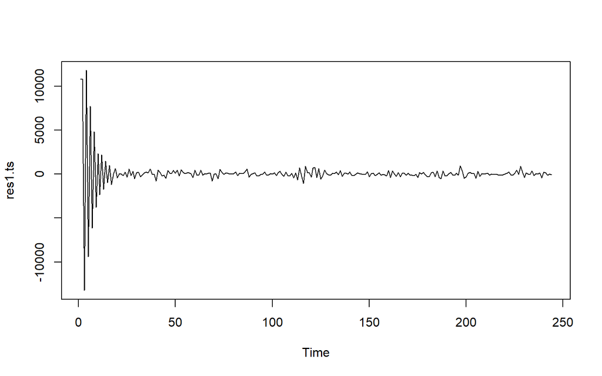

```r
res1<-garch11@fit$residuals
res1.ts<-ts(res1)
plot.ts(res1.ts)
```

Didapatkan nilai AIC sebesar 14.918 dengan semua parameter signifikan (p-value < 0.05) dan semua ARCH LM Test signifikan (p-value > 0.05)

### GARCH(1,2)

```r
garch11 <- rugarch::ugarchspec(mean.model = list(armaOrder = c(2,2), include.mean = FALSE),
                     variance.model = list(model = "sGARCH",garchOrder=c(1,2)))
garch11 <- rugarch::ugarchfit(data = train.diff, spec = garch11)
garch11
```

```
##
## *---------------------------------*
## *          GARCH Model Fit        *
## *---------------------------------*
##
## Conditional Variance Dynamics
## -----------------------------------
## GARCH Model  : sGARCH(1,2)
## Mean Model   : ARFIMA(2,0,2)
## Distribution : norm
##
## Optimal Parameters
## ------------------------------------
##          Estimate  Std. Error  t value Pr(>|t|)
## ar1    1.1236e-01  3.5387e-02   3.1753 0.001497
## ar2    8.7815e-01  3.4727e-02  25.2869 0.000000
## ma1    1.0581e+00  7.5801e-02  13.9589 0.000000
## ma2    2.1352e-01  6.5974e-02   3.2365 0.001210
## omega  2.2926e+04  7.2390e+03   3.1670 0.001540
## alpha1 2.7909e-01  1.0074e-01   2.7705 0.005597
## beta1  4.5706e-01  3.5635e-01   1.2826 0.199635
## beta2  0.0000e+00  2.5258e-01   0.0000 1.000000
##
## Robust Standard Errors:
##          Estimate  Std. Error  t value Pr(>|t|)
## ar1    1.1236e-01  7.7560e-02  1.44875 0.147408
## ar2    8.7815e-01  7.5759e-02 11.59136 0.000000
## ma1    1.0581e+00  4.7489e-01  2.22813 0.025872
## ma2    2.1352e-01  3.8175e-01  0.55934 0.575932
## omega  2.2926e+04  1.8829e+04  1.21759 0.223380
## alpha1 2.7909e-01  3.7352e-01  0.74718 0.454954
## beta1  4.5706e-01  8.2399e-01  0.55469 0.579109
## beta2  0.0000e+00  4.6487e-01  0.00000 1.000000
##
## LogLikelihood : -1797.321
##
## Information Criteria
## ------------------------------------
##
## Akaike       14.798
```

[output cut: 49 more lines]

```
## Negative Sign Bias  0.2145 8.303e-01
## Positive Sign Bias  6.5600 3.301e-10 ***
## Joint Effect       43.3776 2.046e-09 ***
##
##
## Adjusted Pearson Goodness-of-Fit Test:
## ------------------------------------
##   group statistic p-value(g-1)
## 1    20     17.15       0.5799
## 2    30     43.95       0.0371
## 3    40     37.64       0.5319
## 4    50     50.26       0.4232
##
##
## Elapsed time : 0.28775
```

Didapatkan nilai AIC sebesar 14.798 dengan beberapa parameter yang tidak signifikan (p-value < 0.05) dan semua ARCH LM Test signifikan (p-value > 0.05)

### GARCH(1,3)

```r
garch11 <- rugarch::ugarchspec(mean.model = list(armaOrder = c(2,2), include.mean = FALSE),
                     variance.model = list(model = "sGARCH",garchOrder=c(1,3)))
garch11 <- rugarch::ugarchfit(data = train.diff, spec = garch11)
garch11
```

```
##
## *---------------------------------*
## *          GARCH Model Fit        *
## *---------------------------------*
##
## Conditional Variance Dynamics
## -----------------------------------
## GARCH Model  : sGARCH(1,3)
## Mean Model   : ARFIMA(2,0,2)
## Distribution : norm
##
## Optimal Parameters
## ------------------------------------
##           Estimate  Std. Error  t value Pr(>|t|)
## ar1     8.0997e-01  2.0537e-02 39.43931 0.000000
## ar2     1.8320e-01  2.0411e-02  8.97545 0.000000
## ma1     1.5122e-02  6.2524e-02  0.24187 0.808883
## ma2    -8.9870e-03  4.3041e-02 -0.20880 0.834608
## omega   2.5829e+04  5.3677e+03  4.81185 0.000001
## alpha1  1.9445e-01  7.4672e-02  2.60410 0.009212
## beta1   4.8010e-01  2.8530e-01  1.68277 0.092420
## beta2   0.0000e+00  4.2823e-01  0.00000 1.000000
## beta3   0.0000e+00  1.8359e-01  0.00000 1.000000
##
## Robust Standard Errors:
##           Estimate  Std. Error   t value Pr(>|t|)
## ar1     8.0997e-01  3.4270e-03 236.35483 0.000000
## ar2     1.8320e-01  2.3240e-03  78.82647 0.000000
## ma1     1.5122e-02  4.6900e-02   0.32244 0.747119
## ma2    -8.9870e-03  2.9808e-02  -0.30149 0.763043
## omega   2.5829e+04  1.1254e+04   2.29504 0.021731
## alpha1  1.9445e-01  9.0796e-02   2.14164 0.032222
## beta1   4.8010e-01  4.6106e-01   1.04130 0.297738
## beta2   0.0000e+00  6.1991e-01   0.00000 1.000000
## beta3   0.0000e+00  3.0254e-01   0.00000 1.000000
##
## LogLikelihood : -1829.232
##
## Information Criteria
## ------------------------------------
```

[output cut: 52 more lines]

```
## Negative Sign Bias   0.1474 8.829e-01
## Positive Sign Bias  13.7288 5.153e-32 ***
## Joint Effect       189.8988 6.419e-41 ***
##
##
## Adjusted Pearson Goodness-of-Fit Test:
## ------------------------------------
##   group statistic p-value(g-1)
## 1    20     27.15      0.10126
## 2    30     39.52      0.09202
## 3    40     45.84      0.20970
## 4    50     59.69      0.14093
##
##
## Elapsed time : 0.216794
```

Didapatkan nilai AIC sebesar 15.067 dengan beberapa parameter yang tidak signifikan (p-value < 0.05) dan semua ARCH LM Test signifikan (p-value > 0.05)